# Part I (Flights Data Exploration)

## Preliminary Wrangling

> Hello Dear reader. This document explores a dataset reporting flights in US including carriers, arrival and depature delays and reasons for delays, from 1987 to 2008.

```python
# Import all modules and packages needed for wrangling,and plots
import numpy as np
import pandas as pd

import matplotlib.pyplot as plt
import seaborn as sb
import glob

%matplotlib inline
```

First look in all data from 1987 to 2008 about structure before concat contents My laptop could not support more than 3Gb of data to be read. So i decided to restrict the data exploration on the 4 last years (2005-2008)

```python
flights_datasets = glob.glob('./Data_set_folder/*.csv',recursive=True)
flights_datasets
```

```
['./Data_set_folder\\2005.csv',
 './Data_set_folder\\2006.csv',
 './Data_set_folder\\2007.csv',
 './Data_set_folder\\2008.csv']
```

```python
full_flight_dataset = []
for i in range(len(flights_datasets)):
    df = pd.read_csv(flights_datasets[i])
    #All files contains a big quantity of data
    #print('For the flight dataset {}'.format(i)+':\nShape :',df.shape,'\nColumns :\n',df.dtypes)
    full_flight_dataset.append(df)
full_flights = pd.concat(full_flight_dataset,join ='inner',ignore_index=True)
```

```python
print(full_flights.shape)
print(full_flights.dtypes)
print(full_flights.head(5))
```

```
(24124950, 29)
Year                   int64
Month                  int64
DayofMonth             int64
DayOfWeek              int64
DepTime              float64
CRSDepTime             int64
ArrTime              float64
CRSArrTime             int64
UniqueCarrier         object
FlightNum              int64
TailNum               object
ActualElapsedTime    float64
CRSElapsedTime       float64
AirTime              float64
ArrDelay             float64
DepDelay             float64
Origin                object
Dest                  object
Distance               int64
TaxiIn               float64
TaxiOut              float64
Cancelled              int64
CancellationCode      object
Diverted               int64
CarrierDelay         float64
WeatherDelay         float64
NASDelay             float64
SecurityDelay        float64
LateAircraftDelay    float64
dtype: object
   Year  Month  DayofMonth  DayOfWeek  DepTime  CRSDepTime  ArrTime  \
0  2005      1          28          5   1603.0        1605   1741.0
1  2005      1          29          6   1559.0        1605   1736.0
2  2005      1          30          7   1603.0        1610   1741.0
3  2005      1          31          1   1556.0        1605   1726.0
4  2005      1           2          7   1934.0        1900   2235.0

   CRSArrTime UniqueCarrier  FlightNum  ... TaxiIn  TaxiOut  Cancelled  \
0        1759            UA        541  ...    4.0     23.0          0
1        1759            UA        541  ...    6.0     15.0          0
2        1805            UA        541  ...    9.0     18.0          0
3        1759            UA        541  ...   11.0     10.0          0
4        2232            UA        542  ...    5.0     10.0          0

   CancellationCode  Diverted  CarrierDelay WeatherDelay NASDelay  \
0               NaN         0           0.0          0.0      0.0
1               NaN         0           0.0          0.0      0.0
2               NaN         0           0.0          0.0      0.0
3               NaN         0           0.0          0.0      0.0
4               NaN         0           0.0          0.0      0.0

   SecurityDelay  LateAircraftDelay
0            0.0                0.0
1            0.0                0.0
2            0.0                0.0
3            0.0                0.0
4            0.0                0.0

[5 rows x 29 columns]
```

```python
full_flights.to_csv('flights_dataset.csv',index=False)
```

> Overview of data content

[output not shown]

Before start, i decided to reduce the number of parameter to those i put in quote mark just above. I will make my analysis on potential factors wich impact the delay of flights and provide answer to these questions:

- Are there certain destination or arrival cities that are home to more delays or cancellations?
- What are the main factors behind the cancellation of flights?
- What are the preferred times for flights to occur? Are there any changes over multiple years?

```python
#Loadin of dataset
df = pd.read_csv('./flights_dataset.csv')
```

```python
#Columns to be used in data
cols_selected = ['Year', 'Month', 'DayofMonth', 'DayOfWeek', 'ArrDelay',
       'DepDelay','Origin','Dest','Cancelled', 'CancellationCode', 'Diverted', 'CarrierDelay',
       'WeatherDelay', 'NASDelay', 'SecurityDelay', 'LateAircraftDelay']
df= df[cols_selected]
```

```python
df.duplicated().sum()
```

```
445239
```

```python
df.isnull().sum()
```

```
Year                        0
Month                       0
DayofMonth                  0
DayOfWeek                   0
ArrDelay               533901
DepDelay               480854
Origin                      0
Dest                        0
Cancelled                   0
CancellationCode     23644094
Diverted                    0
CarrierDelay          1804634
WeatherDelay          1804634
NASDelay              1804634
SecurityDelay         1804634
LateAircraftDelay     1804634
dtype: int64
```

Then i will perform the follows operations for assessment:

- Drop duplicated rows
- Replace Month number by string(JAN-DEC)
- Replace DayofWeek number by string(Monday to Sunday)

```python
df.drop_duplicates(inplace=True)
```

```python
df['CancellationCode'].replace({'A':'Carrier','B':'Weather', 'C':'NAS', 'D':'Security'}, inplace =True)
df.CancellationCode.value_counts()
```

```
Carrier     185734
Weather     106895
NAS          71434
Security       243
Name: CancellationCode, dtype: int64
```

```python
df['Month'].replace({1:'JAN',2:'FEB',3:'MAR',4:'APR',5:'MAY',6:'JUN',7:'JUL',8:'AUG',9:'SEP',10:'OCT',11:'NOV',12:'DEC'}, inplace=True)
```

```python
df.Month.value_counts()
```

```
MAR    2432247
JAN    2349900
APR    2348654
FEB    2160648
AUG    1882110
JUL    1869731
MAY    1815193
JUN    1806327
OCT    1802967
DEC    1755869
NOV    1729391
SEP    1726674
Name: Month, dtype: int64
```

```python
df['DayOfWeek'].replace({1:'Monday',2:'Tuesday',3:'Wednesday',4:'Thursday',5:'Friday',6:'Saturday',7:'Sunday'},inplace = True)
df.DayOfWeek.value_counts()

# convert Month, Day of week into ordered categorical types
ordinal_var_dict = {'Month': ['JAN','FEB','MAR','APR','MAY','JUN','JUL','AUG','SEP','OCT','NOV','DEC'],
                    'DayOfWeek': ['Monday','Tuesday','Wednesday','Thursday','Friday','Saturday','Sunday'],
                    'CancellationCode': ['Carrier','Weather','NAS','Security']}

for var in ordinal_var_dict:
    ordered_var = pd.api.types.CategoricalDtype(ordered = True,
                                                categories = ordinal_var_dict[var])
    df[var] = df[var].astype(ordered_var)
```

```python
print(df.describe())
```

```
               Year    DayofMonth      ArrDelay      DepDelay     Cancelled  \
count  2.367971e+07  2.367971e+07  2.326272e+07  2.331541e+07  2.367971e+07
mean   2.006215e+03  1.572035e+01  9.055804e+00  1.037067e+01  1.538465e-02
std    9.772517e-01  8.782317e+00  3.731568e+01  3.422291e+01  1.230771e-01
min    2.005000e+03  1.000000e+00 -9.390000e+02 -1.200000e+03  0.000000e+00
25%    2.005000e+03  8.000000e+00 -9.000000e+00 -4.000000e+00  0.000000e+00
50%    2.006000e+03  1.600000e+01 -1.000000e+00  0.000000e+00  0.000000e+00
75%    2.007000e+03  2.300000e+01  1.300000e+01  1.000000e+01  0.000000e+00
max    2.008000e+03  3.100000e+01  2.598000e+03  2.601000e+03  1.000000e+00

           Diverted  CarrierDelay  WeatherDelay      NASDelay  SecurityDelay  \
count  2.367971e+07  2.191220e+07  2.191220e+07  2.191220e+07   2.191220e+07
mean   2.225069e-03  3.820057e+00  7.769323e-01  3.982018e+00   2.675382e-02
std    4.711813e-02  2.027372e+01  9.352461e+00  1.639711e+01   1.163945e+00
min    0.000000e+00  0.000000e+00  0.000000e+00 -4.900000e+01   0.000000e+00
25%    0.000000e+00  0.000000e+00  0.000000e+00  0.000000e+00   0.000000e+00
50%    0.000000e+00  0.000000e+00  0.000000e+00  0.000000e+00   0.000000e+00
75%    0.000000e+00  0.000000e+00  0.000000e+00  0.000000e+00   0.000000e+00
max    1.000000e+00  2.580000e+03  1.510000e+03  1.392000e+03   3.920000e+02

       LateAircraftDelay
count       2.191220e+07
mean        4.959000e+00
std         2.070049e+01
min         0.000000e+00
25%         0.000000e+00
50%         0.000000e+00
75%         0.000000e+00
max         1.366000e+03
```

### What is the structure of your dataset?

There are more than 24 Millions flights in the dataset with at least 20 features.

Most variables are numeric in nature as year, month, DayofMonth, DayOfWeek, ArrDelay, DepDelay,CarrierDelay, Cancelled, Diverted, WeatherDelay, NASDelay, SecurityDelay, LateAircraftDelay but the variables Origin, Dest, CancellationCode are categorical. Month: JAN - DEC  
DayOfWeek: Monday - Sunday  
CancellationCode: Carrier, Weather ,NAS ,Security

### What is/are the main feature(s) of interest in your dataset?

I'm most interested in figuring out what features are best to predict if a flight will be delayed or cancelled. Also that could be interesing to find the preferred times for flights.

### What features in the dataset do you think will help support your investigation into your feature(s) of interest?

I expect that flights are delayed and cancelled mainly due to Weather and Security.I also think that the preferred times for flights to occur are holidays (between july , august and september) whenenver the year. I have to explore variables linked to delay and flights cancellation.

## Univariate Exploration

I'll start by looking at the distribution of the main variables of interest: `Arrival Delay`, `Departure Delay`.

#### What about distribution of Departure and arrival delay ?

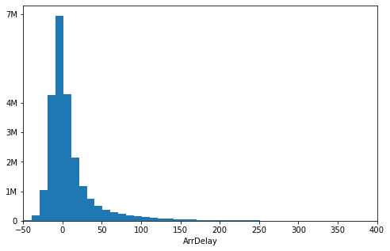

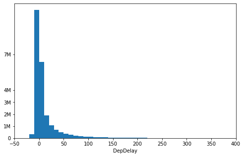

```python
def hist_delay(delay_parm, xlimx, xlimy,tick, tick_label, xlabel='', ylabel=''):
    """Plot the histogramm of delay based on standard scale"""
    binsize = 10
    bins = np.arange(df[delay_parm].min(), df[delay_parm].max()+binsize, binsize)
    plt.figure(figsize=[8, 5])
    plt.hist(data = df, x = delay_parm,bins = bins)
    plt.xlim(xlimx,xlimy)
    plt.yticks(tick,tick_label)
    plt.xlabel(delay_parm)


def hist_log_delays(delay_parm,tick, tick_label, xlabel='', ylabel=''):
    """Plot the histogramm of delay based on log scale"""
    # there's a long tail in the distribution, so let's put it on a log scale instead
    log_binsize = 0.05
    bins = 10 ** np.arange(0.5, np.log10(df[delay_parm].max())+log_binsize, log_binsize)
    plt.figure(figsize=[8, 5])
    plt.hist(data = df, x = delay_parm, bins = bins)
    plt.xscale('log')
    plt.xticks(tick, tick_label)
    plt.xlabel(xlabel)
    plt.show()

delay_factors =['ArrDelay','DepDelay']
delay_factors_label = ['Arrival Delay (mn)','Departure Delay (mn)']
for i in range(len(delay_factors)):
    hist_delay(delay_factors[i],-50,400, [0,1e6,2e6,3e6,4e6,7e6],[0,'1M','2M','3M','4M','7M'],delay_factors_label[i])
```

The distribution is unimodal about the arrival delay time and slightly skewed at right. But that's normal because most of flight haven't delay at arrival.We can notice that the negative Arrival delay means that the airplane arrived early. Now let's take a look on the DepDelay.

I would restraints my analysis on flights started at time. In order to perform a log scale transformation.

#### What about the distribution of departure and arrival delays after the scale transformation?

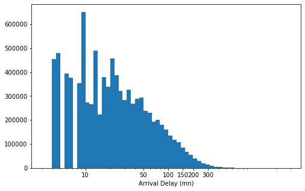

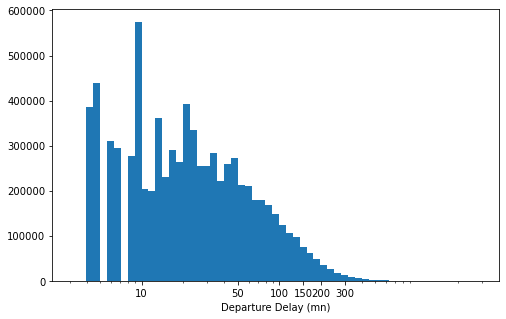

```python
for i in range(len(delay_factors)):
    hist_log_delays(delay_factors[i],[10, 50, 100, 150, 200, 300], [10, 50, 100, 150, 200, 300],delay_factors_label[i])
```

The depature delay has a long-tailed distribution, with a lot of ocurrence of 9 mn. The delay distribution looks roughly bimodal , with one peak between 7 and 10 , and another between 25 and 40. Perhaps some frequent depature delays from specific origin/town. Now i want to look the global dataset based on years , months,and days week.

Something could disturb my undestanding about the departure delay. That could be very difficult for passengers to accept the departures in advance. So i will remove the negative departures delays from dataset. Howerver i will keep negative delays.

For plotings and further analysis ,as we have a lot of destinations and origins, i will take the 10 more frequent.

```python
#We will take departure delays superior to 0 or flights departed on time including None values due to cancelled flghts
df_1 = df.query('DepDelay >= 0 | DepDelay != DepDelay')
df_1.describe()
```

|  | Year | DayofMonth | ArrDelay | DepDelay | Cancelled | Diverted | CarrierDelay | WeatherDelay | NASDelay | SecurityDelay | LateAircraftDelay |
| --- | --- | --- | --- | --- | --- | --- | --- | --- | --- | --- | --- |
| count | 1.260674e+07 | 1.260674e+07 | 1.220747e+07 | 1.224244e+07 | 1.260674e+07 | 1.260674e+07 | 1.191391e+07 | 1.191391e+07 | 1.191391e+07 | 1.191391e+07 | 1.191391e+07 |
| mean | 2.006199e+03 | 1.581879e+01 | 2.266591e+01 | 2.390164e+01 | 2.889756e-02 | 2.773516e-03 | 6.977469e+00 | 1.427077e+00 | 6.151608e+00 | 4.917975e-02 | 9.111542e+00 |
| std | 9.769741e-01 | 8.743971e+00 | 4.602913e+01 | 4.268247e+01 | 1.675186e-01 | 5.259110e-02 | 2.705744e+01 | 1.263519e+01 | 2.093880e+01 | 1.577949e+00 | 2.737169e+01 |
| min | 2.005000e+03 | 1.000000e+00 | -1.480000e+02 | 0.000000e+00 | 0.000000e+00 | 0.000000e+00 | 0.000000e+00 | 0.000000e+00 | -1.000000e+00 | 0.000000e+00 | 0.000000e+00 |
| 25% | 2.005000e+03 | 8.000000e+00 | -2.000000e+00 | 1.000000e+00 | 0.000000e+00 | 0.000000e+00 | 0.000000e+00 | 0.000000e+00 | 0.000000e+00 | 0.000000e+00 | 0.000000e+00 |
| 50% | 2.006000e+03 | 1.600000e+01 | 9.000000e+00 | 8.000000e+00 | 0.000000e+00 | 0.000000e+00 | 0.000000e+00 | 0.000000e+00 | 0.000000e+00 | 0.000000e+00 | 0.000000e+00 |
| 75% | 2.007000e+03 | 2.300000e+01 | 3.000000e+01 | 2.800000e+01 | 0.000000e+00 | 0.000000e+00 | 0.000000e+00 | 0.000000e+00 | 0.000000e+00 | 0.000000e+00 | 0.000000e+00 |
| max | 2.008000e+03 | 3.100000e+01 | 2.598000e+03 | 2.601000e+03 | 1.000000e+00 | 1.000000e+00 | 2.580000e+03 | 1.510000e+03 | 1.386000e+03 | 3.920000e+02 | 1.366000e+03 |

### How many flights have we in dataset on 10 most common Origins and Destination?

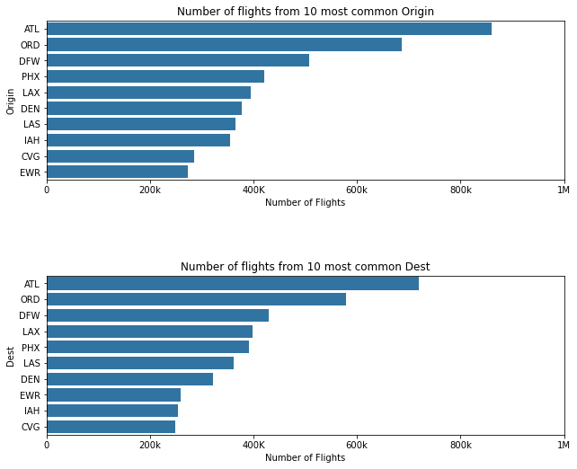

```python
sorted_org = df_1['Origin'].value_counts()[:10]
df_org_sorted = df_1[df_1['Origin'].isin(sorted_org.index)]
sorted_dest = df_1['Dest'].value_counts()[:10]
df_dest_sorted = df_1[df['Dest'].isin(sorted_dest.index)]

countries = ['Origin','Dest']
df_list = [df_org_sorted,df_dest_sorted]
sorted_countries = [sorted_org,sorted_dest]
plt.figure(figsize=[10,8])
plt.subplots_adjust(left=0.1,
                    bottom=0.1,
                    right=0.9,
                    top=0.9,
                    wspace=0.1,
                    hspace=0.6)
for i in range(len(countries)):
    plt.subplot(2,1,i+1)
    color_base = sb.color_palette()[0]
    sb.countplot(data = df_list[i], y = countries[i], color= color_base,order = sorted_countries[i].index)
    plt.title('Number of flights from 10 most common '+ countries[i])
    plt.xticks([0,0.2e6,0.4e6,0.6e6,0.8e6,1e6],[0,'200k','400K','600k','800k','1M'])
    plt.xlabel('Number of Flights')
    plt.ylabel(countries[i])
plt.show()
```

So in dataset, most of flights are made on ATL, ORD, DFW.

I want apply my next investigations on these 10 destinations and origin. So let's merge these data.

```python
df_flights = df_org_sorted
df_flights = pd.concat([df_org_sorted,df_dest_sorted],ignore_index=True)
df_flights.drop_duplicates(inplace = True)
```

### What is flights number per time slot on 10 most common countries?

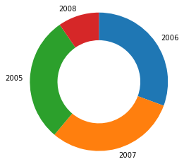

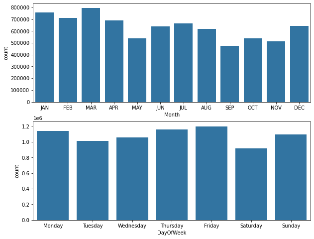

```python
# let's plot  each ordinal variable's distribution.
sorted_years = df_flights.Year.value_counts()
default_color = sb.color_palette()[0]
plt.pie(sorted_years, labels = sorted_years.index,startangle= 90, counterclock=False, wedgeprops={'width':0.4})
plt.axis('square')


fig, ax = plt.subplots(nrows = 2, figsize = [10,8])
sb.countplot(data = df_flights, x = 'Month', color = default_color, ax = ax[0])
sb.countplot(data = df_flights, x = 'DayOfWeek', color = default_color, ax = ax[1])

plt.show()
```

The amount of flights in dataset are more between 2005 and 2007. We have few flights in 2008 by refering to data shape of these years. Based on 10 most common destinations,the majority of flights are made in March and very few flights on september. Most flights are scheduled for Friday and Thursday and less on saturdays.

Now let's focus on the cancelled or diverted flights.

### How many cancelled and diverted flights have we in dataset?

```python
df_flights.CancellationCode.value_counts()
```

```
Carrier     112265
Weather      69462
NAS          54027
Security       186
Name: CancellationCode, dtype: int64
```

[figure not shown]

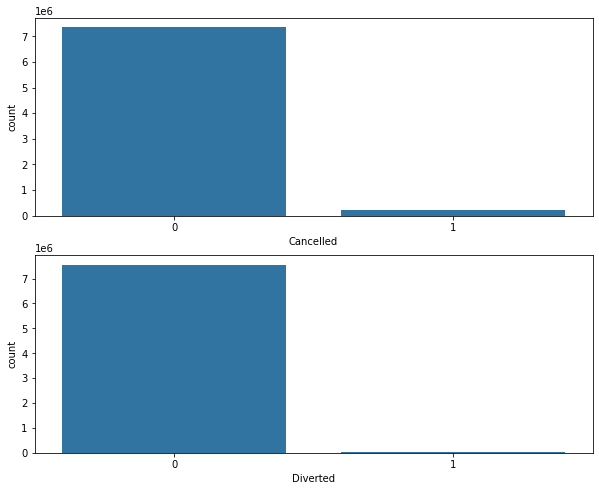

```python
sorted_cancelled = df_flights.CancellationCode.value_counts()
default_color = sb.color_palette()[0]
plt.pie(sorted_years, labels = sorted_cancelled.index,startangle= 90, counterclock=False, wedgeprops={'width':0.4})
plt.axis('square')
fig, ax = plt.subplots(nrows=2, figsize = [10,8])
sb.countplot(data = df_flights, x = 'Cancelled', color = default_color, ax = ax[0])
sb.countplot(data = df_flights, x = 'Diverted', color = default_color, ax = ax[1])

plt.show()
```

Most of flights which are delayed due to Carrier, and after weather, very few delayed by Security.We can ignore the flights diverted. They are negligible. I want take a look also on CancellationCode distributions.

### What about Cancellation factors distributions in dataset?

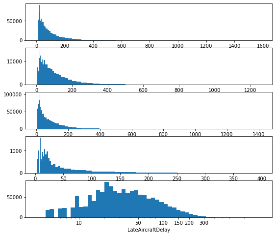

```python
log_binsize = 0.05
fig, ax = plt.subplots(nrows = 5,figsize=[9,8])

variables = ['CarrierDelay','WeatherDelay', 'NASDelay', 'SecurityDelay', 'LateAircraftDelay']

for i in range(len(variables)):
    var = variables[i]
    bins = 10 ** np.arange(0.5, np.log10(df_flights[var].max())+log_binsize, log_binsize)
    ax[i].hist(data = df_flights, x = var, bins = bins)
    plt.xscale('log')
    ax[i].set_xlabel('{}'.format(var))
plt.xticks([10, 50, 100, 150, 200, 300], [10, 50, 100, 150, 200, 300])
plt.show()
```

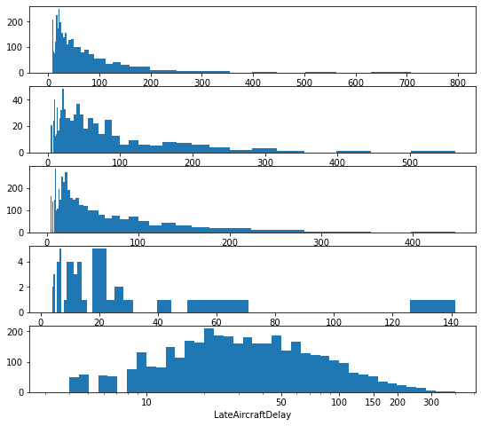

```python
df_samp = df_flights.sample(20000)
log_binsize = 0.05
fig, ax = plt.subplots(nrows = 5,figsize=[9,8])

variables = ['CarrierDelay','WeatherDelay', 'NASDelay', 'SecurityDelay', 'LateAircraftDelay']

for i in range(len(variables)):
    var = variables[i]
    bins = 10 ** np.arange(0.5, np.log10(df_samp[var].max())+log_binsize, log_binsize)
    ax[i].hist(data = df_samp, x = var, bins = bins)
    plt.xscale('log')
    ax[i].set_xlabel('{}'.format(var))
plt.xticks([10, 50, 100, 150, 200, 300], [10, 50, 100, 150, 200, 300])
plt.show()
```

Except the Late Aircraft Delay, and the security delay which looks a little discrete, the cancellation reasons have a similar distribution which decreases from 0 to a maximum of 1000 mn on Carrier distribution. But i was not completly sure that Carrier is the main cause of flights cancellation. Perhaps due to the high number of flights on some destinations cancelled due to Carrier. So i tooke a look on 20000 random flights. The behaviour is the same

### Discuss the distribution(s) of your variable(s) of interest. Were there any unusual points? Did you need to perform any transformations?

Except the Late Aircraft Delay, and the security delay which looks a little discrete, the cancellation reasons have a similar distribution which decreases from 0 to a maximum of 1000 mn on Carrier distribution. But i was not completly sure that Carrier is the main cause of flights cancellation. Perhaps due to the high number of flights on some destinations cancelled due to Carrier. So i tooke a look on 20000 random flights. The behaviour is the same, seems like there are some correlations between cancelation reasons.I discovered that the NASDelay is more present.

*My new hypothesis is that during a specific month , there were a lot of flights cancelled due ether to Carrier or NAS.*

That could be also interesting to discover the destinations that are home to more delays or cancellations. I looked at the data using a log transform because the delay minutes took a large range of values.

### Of the features you investigated, were there any unusual distributions? Did you perform any operations on the data to tidy, adjust, or change the form of the data? If so, why did you do this?

When investigating, i discovered some duplicated rows, that i removed before plot my histograms. For more clarity in my explanations i decided to perform my analysis on 10 most common flight destinations and origins. I will make two explorations, the first on flights delayed and the last on cancelled flights.

## Bivariate Exploration

To start off with, I want to look at the pairwise correlations present between features in the data.

```python
numeric_vars=['CarrierDelay','WeatherDelay', 'NASDelay', 'SecurityDelay', 'LateAircraftDelay','ArrDelay','DepDelay']
categoric_cancellation_vars = ['CancellationCode','Dest','Origin','Month']
numeric_delay_features = ['ArrDelay','DepDelay']
```

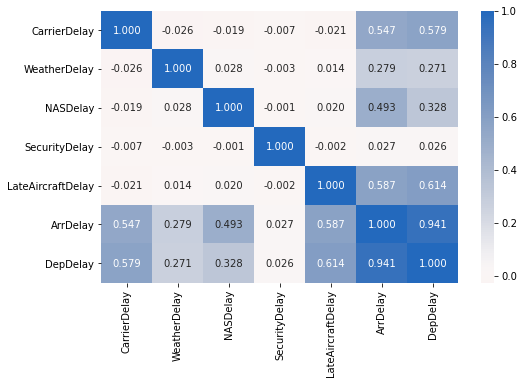

```python
# correlation plot
plt.figure(figsize = [8, 5])
sb.heatmap(df_flights[numeric_vars].corr(), annot = True, fmt = '.3f',
           cmap = 'vlag_r', center = 0)
plt.show()
```

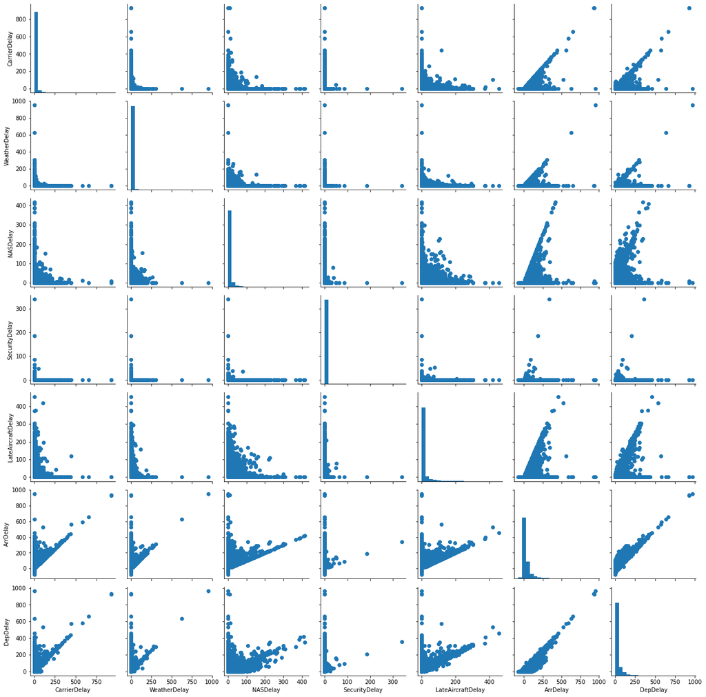

```python
# plot matrix: sample 20000 flights so that plots are clearer and
# they render faster
df_samp = df_flights.sample(20000)

g = sb.PairGrid(data = df_samp, vars = numeric_vars)
g = g.map_diag(plt.hist, bins = 20);
g.map_offdiag(plt.scatter)
```

Let's moove on to looking how Deapture and Arrival delays are correlated with Destination and Origin.

### how Deapture and Arrival delays are correlated with Destination and Origin?

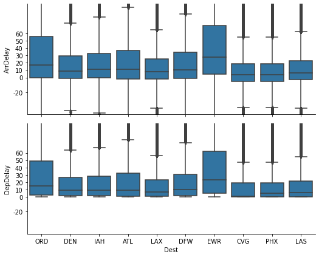

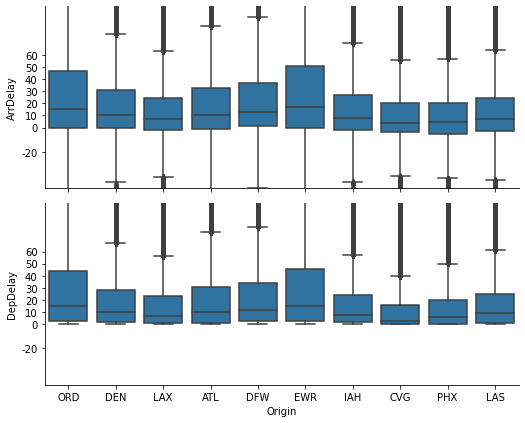

```python
# plot matrix of numeric features against categorical features.

def boxgrid(x, y, **kwargs):
    """ Quick hack for creating box plots with seaborn's PairGrid. """
    default_color = sb.color_palette()[0]
    sb.boxplot(x, y, color = default_color)
    plt.yticks([-20,0,10,20,30,40,50,60,120],[-20,0,10,20,30,40,50,60,120])
    plt.ylim(-50,100)

plt.figure(figsize = [16, 10])
g = sb.PairGrid(data = df_dest_sorted, y_vars = numeric_delay_features, x_vars = categoric_cancellation_vars[1],
                size = 3, aspect = 2.5)
g.map(boxgrid)
p = sb.PairGrid(data = df_org_sorted, y_vars = numeric_delay_features, x_vars = categoric_cancellation_vars[2],
                size = 3, aspect = 2.5)
p.map(boxgrid)

plt.show();
```

```python
g_org = df_org_sorted.groupby('Origin').mean().sort_values(by=['DepDelay'],ascending =False)
g_org
```

| Origin | Year | DayofMonth | ArrDelay | DepDelay | Cancelled | Diverted | CarrierDelay | WeatherDelay | NASDelay | SecurityDelay | LateAircraftDelay |
| --- | --- | --- | --- | --- | --- | --- | --- | --- | --- | --- | --- |
| EWR | 2006.240657 | 15.778364 | 34.434480 | 34.711746 | 0.045752 | 0.002549 | 8.151511 | 1.483022 | 9.218192 | 0.118621 | 16.724689 |
| ORD | 2006.264355 | 15.787146 | 32.418337 | 33.277879 | 0.045496 | 0.002449 | 8.822553 | 1.781683 | 6.393077 | 0.012385 | 15.722980 |
| DFW | 2006.229979 | 15.840415 | 26.801047 | 26.803657 | 0.031365 | 0.002371 | 8.239302 | 3.052551 | 5.889225 | 0.011839 | 9.544316 |
| ATL | 2006.164264 | 15.794374 | 23.599948 | 24.917839 | 0.027496 | 0.002668 | 8.796277 | 2.451288 | 5.262463 | 0.019037 | 7.832743 |
| DEN | 2006.311773 | 15.871954 | 23.700846 | 23.793779 | 0.020811 | 0.002327 | 7.167082 | 1.213560 | 4.818284 | 0.021962 | 10.837588 |
| IAH | 2006.236168 | 15.906217 | 21.366424 | 22.025830 | 0.016418 | 0.003011 | 6.332426 | 2.302790 | 6.843829 | 0.177333 | 6.888146 |
| LAS | 2006.173492 | 15.817000 | 17.013890 | 20.652093 | 0.012414 | 0.002400 | 5.288556 | 0.301402 | 3.449483 | 0.065220 | 9.414319 |
| LAX | 2006.206877 | 15.833293 | 17.505301 | 19.806215 | 0.019202 | 0.001893 | 7.038030 | 0.369525 | 3.596446 | 0.054364 | 7.352730 |
| PHX | 2006.225006 | 15.833451 | 13.573550 | 17.513328 | 0.012911 | 0.002385 | 6.446871 | 0.348564 | 3.106402 | 0.057749 | 5.523153 |
| CVG | 2005.986759 | 15.779801 | 14.242384 | 15.043866 | 0.028445 | 0.002459 | 6.497802 | 1.708717 | 5.005071 | 0.060179 | 1.895901 |

```python
g_dest = df_dest_sorted.groupby('Dest').mean().sort_values(by=['DepDelay'],ascending =False)
g_dest
```

| Dest | Year | DayofMonth | ArrDelay | DepDelay | Cancelled | Diverted | CarrierDelay | WeatherDelay | NASDelay | SecurityDelay | LateAircraftDelay |
| --- | --- | --- | --- | --- | --- | --- | --- | --- | --- | --- | --- |
| EWR | 2006.254346 | 15.777523 | 46.923366 | 44.082149 | 0.049048 | 0.005458 | 4.721761 | 1.583123 | 29.721385 | 0.053596 | 10.996874 |
| ORD | 2006.285354 | 15.769040 | 38.796424 | 37.295398 | 0.059529 | 0.003410 | 6.558676 | 1.154686 | 18.148886 | 0.030090 | 12.803093 |
| DFW | 2006.240656 | 15.827199 | 26.297002 | 26.947480 | 0.040201 | 0.005978 | 7.071759 | 1.889994 | 5.577156 | 0.034888 | 12.118706 |
| ATL | 2006.143437 | 15.808628 | 26.724104 | 26.726365 | 0.036175 | 0.003187 | 7.840133 | 1.898407 | 10.701952 | 0.031779 | 7.330809 |
| IAH | 2006.236828 | 15.965890 | 27.031460 | 26.456427 | 0.024905 | 0.006561 | 6.774961 | 1.528537 | 7.969109 | 0.088024 | 11.425551 |
| DEN | 2006.329153 | 15.887275 | 22.874119 | 24.143354 | 0.027107 | 0.001603 | 7.662567 | 1.256134 | 3.985113 | 0.049610 | 10.570260 |
| LAX | 2006.195662 | 15.809187 | 18.598306 | 20.392303 | 0.020488 | 0.001264 | 6.659727 | 0.778588 | 3.905053 | 0.061150 | 8.380309 |
| LAS | 2006.180596 | 15.805951 | 16.184051 | 18.916460 | 0.011437 | 0.001513 | 4.924054 | 0.701498 | 3.912656 | 0.049254 | 8.398809 |
| CVG | 2005.959645 | 15.757053 | 15.274847 | 17.528324 | 0.041568 | 0.001746 | 7.646938 | 3.294211 | 3.147525 | 0.029450 | 2.422226 |
| PHX | 2006.203117 | 15.814537 | 13.344704 | 17.326270 | 0.018060 | 0.001653 | 5.561582 | 0.616413 | 2.790517 | 0.062902 | 6.451672 |

```python
origin_gap_delay = g_org.reset_index()[['Origin','DepDelay','ArrDelay']]
origin_gap_delay['offset_delay'] = origin_gap_delay['DepDelay'] - origin_gap_delay['ArrDelay']
origin_gap_delay.sort_values(by = 'offset_delay', ascending =False)
origin_gap_delay.rename(columns={'Origin':'country'},inplace =True )
```

```python
dest_gap_delay = g_dest.reset_index()[['Dest','DepDelay','ArrDelay']]
dest_gap_delay['offset_delay'] = dest_gap_delay['DepDelay'] - dest_gap_delay['ArrDelay']
dest_gap_delay.sort_values(by = 'offset_delay', ascending =False)
dest_gap_delay.rename(columns = {'Dest':'country'},inplace = True)
```

```python
flights_gap_delays = pd.concat([origin_gap_delay,dest_gap_delay], ignore_index=True)
flights_gap_delays.groupby('country').mean().sort_values(by = 'offset_delay', ascending =False)
```

| country | DepDelay | ArrDelay | offset_delay |
| --- | --- | --- | --- |
| PHX | 17.419799 | 13.459127 | 3.960672 |
| LAS | 19.784276 | 16.598971 | 3.185306 |
| LAX | 20.099259 | 18.051804 | 2.047456 |
| CVG | 16.286095 | 14.758615 | 1.527479 |
| DEN | 23.968566 | 23.287482 | 0.681084 |
| ATL | 25.822102 | 25.162026 | 0.660076 |
| DFW | 26.875569 | 26.549024 | 0.326544 |
| IAH | 24.241129 | 24.198942 | 0.042187 |
| ORD | 35.286638 | 35.607380 | -0.320742 |
| EWR | 39.396947 | 40.678923 | -1.281975 |

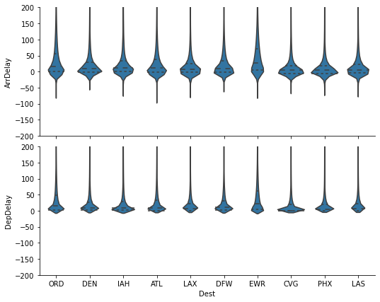

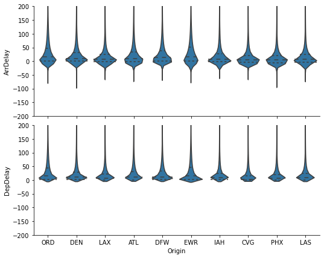

```python
def violingrid(x, y, **kwargs):
    """ Quick hack for creating box plots with seaborn's PairGrid. """
    default_color = sb.color_palette()[0]
    sb.violinplot(x, y, color = default_color,inner = 'quartile')
    plt.ylim(-200,200)
plt.figure(figsize = [16, 10])
g = sb.PairGrid(data = df_dest_sorted, y_vars = numeric_delay_features, x_vars = categoric_cancellation_vars[1],
                size = 3, aspect = 2.5)

g.map(violingrid)

p = sb.PairGrid(data = df_org_sorted, y_vars = numeric_delay_features, x_vars = categoric_cancellation_vars[2],
                size = 3, aspect = 2.5)
p.map(violingrid)
plt.show();
```

That interesting to know , through these 10 destinations or origins, the passenger will have delay at arrival at ORD and EWR no matter when he take departure from any origin.

Finally let's look at relationships the categorical features.

Let's figure out the destinations or arrival cities more subjected to cancellation.

### What flights destinations or arrival cities are more subjected to cancellation?

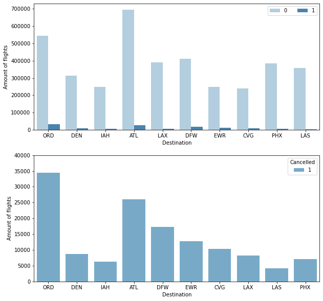

```python
plt.figure(figsize = [10, 10])
# subplot 1: Destination vs Cancelled state
plt.subplot(2, 1, 1)
sb.countplot(data = df_dest_sorted, x = 'Dest', hue = 'Cancelled', palette = "Blues")
plt.ylabel('Amount of flights')
plt.xlabel('Destination')
plt.legend(ncol = 2) # re-arrange legend to reduce overlapping

# subplot 2: Destination vs Cancelled state (zoomed)
ax = plt.subplot(2, 1, 2)
sb.countplot(data = df_dest_sorted[df_dest_sorted['Cancelled']==1], x = 'Dest', hue = 'Cancelled', palette = "Blues")
plt.ylabel('Amount of flights')
ax.set_ylim(0,40000)
plt.xlabel('Destination')
```

We have very few cancelled flights in dataset. And the number of cancelled flight is high at ORD , ATL and DFW.

### What is the number of cancelled flights per city, month and year?

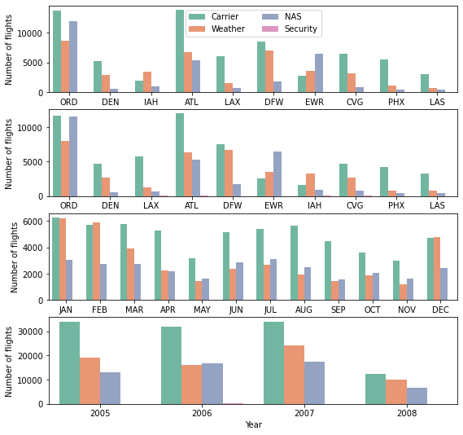

```python
plt.figure(figsize = [9, 9])

# subplot 1: Destination vs CancellationCode
plt.subplot(4, 1, 1)
sb.countplot(data = df_dest_sorted, x = 'Dest', hue = 'CancellationCode', palette = "Set2")
plt.legend(ncol = 2) # re-arrange legend to reduce overlapping
plt.ylabel('Number of flights')
plt.xlabel('Country (Origin or Destination)')

# subplot 2: Origin vs. CancellationCode
ax = plt.subplot(4, 1, 2)
sb.countplot(data = df_org_sorted, x = 'Origin', hue = 'CancellationCode', palette = "Set2")
leg =ax.legend()
leg.remove()
ax.set_ylabel('Number of flights')
ax.set_xlabel('Country (Origin or Destination)')

# subplot 3: Month vs. CancellationCode
ax = plt.subplot(4, 1, 3)
sb.countplot(data = df_org_sorted, x = 'Month', hue = 'CancellationCode', palette = "Set2")
leg =ax.legend()
leg.remove()
ax.set_ylabel('Number of flights')
ax.set_xlabel('Months')

# subplot 4: Year vs. CancellationCode
ax = plt.subplot(4, 1, 4)
sb.countplot(data = df_flights, x = 'Year', hue = 'CancellationCode', palette = "Set2")
leg =ax.legend()
leg.remove()
ax.set_ylabel('Number of flights')
ax.set_xlabel('Year')


plt.show()
```

With the preliminary look at bivariate relationships, i want to loop the relation between the arrival and depature delay with the Late aircraft delay and NASDelay. I will plot on a log scale, the relationship between the depature delay and the LateAircraftDelay, and between the Arrival delay and the NASDelay.

```python
# compute the logarithm of price to make multivariate plotting easier
def log_trans(x, inverse = False):
    """ quick function for computing log and power operations """
    if not inverse:
        return np.log10(x)
    else:
        return np.power(10, x)

df_dest_sorted['Log_ArrDelay'] = df_dest_sorted[df_dest_sorted['ArrDelay']!= 0]['ArrDelay'].apply(log_trans)
df_org_sorted['Log_DepDelay'] = df_org_sorted[df_org_sorted['DepDelay']!= 0]['DepDelay'].apply(log_trans)
```

### How is the relationship between the departure delay and LateAircraft delay ? Between the NAS Delay and the arrival delay?

```python
def scatter_delay(df, delay_param,factor_delay,xlabel,ylabel):
    plt.figure(figsize = [8, 6])
    plt.scatter(data = df, x = delay_param, y = factor_delay, alpha=1/10)
    plt.xlabel(xlabel)
    plt.yscale('log')
    plt.xticks([10, 100, 200, 300, 500], [10, 100, 200, 300, 500])
    plt.yticks([10, 50, 100, 150, 200, 500], [10, 50, 100, 150, 200, 500])
    plt.ylabel(ylabel)
    plt.show()

def scatter_delay_log(df,delay_param,factor_delay,xlabel,ylabel):
    plt.figure(figsize = [8, 6])
    plt.scatter(data = df, x = delay_param, y = factor_delay, alpha=1/10)
    plt.xlabel(xlabel)
    plt.yscale('log')
    plt.yticks([10, 50, 100, 150, 200, 500], [10, 50, 100, 150, 200, 500])
    plt.ylabel(ylabel)
    plt.show()
```

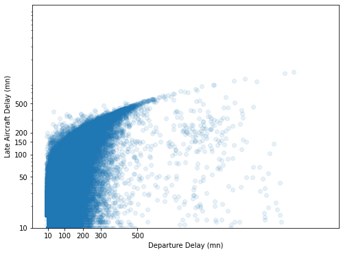

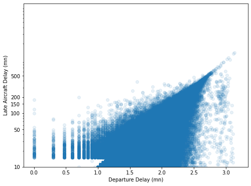

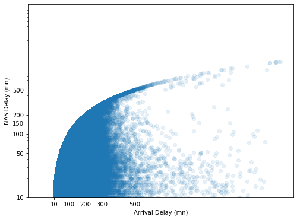

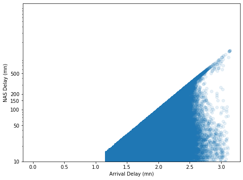

```python
# scatter plot of DepDelay vs. LateAircraftDelay, with log transform on DepDelay axis and ArrDelay vs NASDelay , with log transform on NASDelay
delay_params =['DepDelay','ArrDelay']
factor_delays =['LateAircraftDelay','NASDelay']
xlabels =['Departure Delay (mn)','Arrival Delay (mn)']
delay_params_log =['Log_DepDelay','Log_ArrDelay']
ylabels = ['Late Aircraft Delay (mn)','NAS Delay (mn)']
df_list =[df_org_sorted,df_dest_sorted]
for i in range(len(delay_params)):
    scatter_delay(df_list[i], delay_params[i],factor_delays[i],xlabels[i],ylabels[i])
    scatter_delay_log(df_list[i], delay_params_log[i],factor_delays[i],xlabels[i],ylabels[i])
```

The plot showed that even with a Late aircraft delay of 10 min , we can have a departure delay of more than 250 min and from 100 min of late aircraft delay, the delay at departure can quickly grow up to more than 500 min. So the impact of the late aircraft delay on the depature is important. The impact of NAS Delay on arrival delay is more important. Even with 10 min of NAS Delay , we can have more than 400 min of arrival delay.From 40 min of NAS Delay the arrival delay can quickly grow up to more than 500 min.

The NAS after some research proves to be important to guarantee the landing of an aircraft in better conditions.

## Multivariate Exploration

The main thing I want to explore in this part of the analysis is how the Destination play into the relationship between ArrDelay and DepDelay.

### What is the flights number delayed at arrival per month in 10 most frequent destinations?i

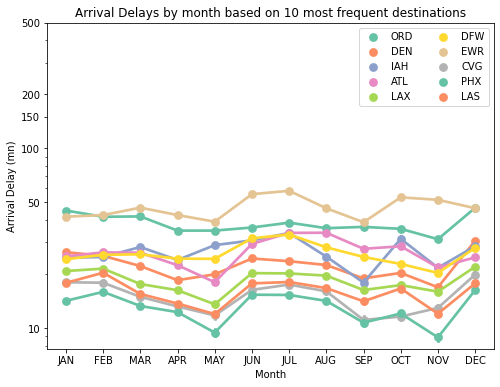

```python
fig = plt.figure(figsize = [8,6])
ax = sb.pointplot(data = df_dest_sorted, x = 'Month', y = 'ArrDelay', hue = 'Dest',
           palette = 'Set2', dodge = 0)
plt.title('Arrival Delays by month based on 10 most frequent destinations')
plt.ylabel('Arrival Delay (mn)')
plt.yscale('log')
plt.yticks([10, 50, 100, 150, 200, 500], [10, 50, 100, 150, 200, 500])
ax.set_yticklabels([],minor = True)
plt.legend(ncol = 2) # re-arrange legend to reduce overlapping
plt.show();
```

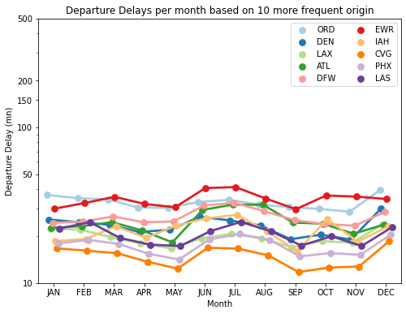

```python
fig = plt.figure(figsize = [8,6])
ax = sb.pointplot(data = df_org_sorted, x = 'Month', y = 'DepDelay', hue = 'Origin',
           palette = 'Paired',dodge = 0.4)
plt.title('Departure Delays per month based on 10 more frequent origin')
plt.ylabel('Departure Delay (mn)')
plt.yscale('log')
plt.yticks([10, 50, 100, 150, 200, 500], [10, 50, 100, 150, 200, 500])
ax.set_yticklabels([],minor = True)
plt.legend(ncol = 2) # re-arrange legend to reduce overlapping
plt.show();
```

The majority of flights delayed at the depature are on **december**, **june** and **july** at **ORD** and **EWR**, followed by **ATL**. The multivariate exploration here showed that there indeed during some specific months,some origin are most subjected to be delayed at departure. For example, in january at ORD.

### What is the offset delay between the 10 most commmon country flights?

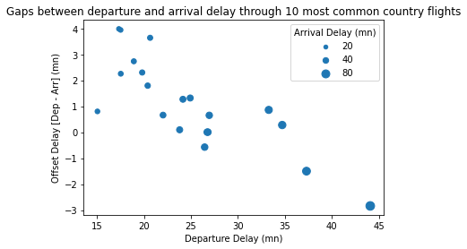

```python
#Let's figure out the Offset delay between the 10 most commmon country flights.

plt.scatter(data = flights_gap_delays, x = 'DepDelay', y='offset_delay',s= flights_gap_delays['ArrDelay']*2)
sizes = [20,40,80]
base_color = sb.color_palette()[0]
legend_obj=[]
for i in sizes:
    legend_obj.append(plt.scatter([],[],s= i,color = base_color))
plt.legend(legend_obj, sizes, title ='Arrival Delay (mn)')
plt.xlabel('Departure Delay (mn)')
plt.ylabel('Offset Delay [Dep - Arr] (mn)')
plt.title('Gaps between departure and arrival delay through 10 most common country flights')
```

By this representation, that's more clear some destination are always subjected to delays no matter when the departure from origin occured. The big points at negative offset in this scatter plot are surely on ORD and EWR.

### What is the flights number delayed at arrival per year in 10 most frequent destinations?

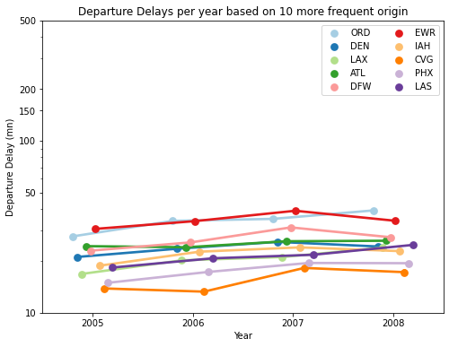

```python
fig = plt.figure(figsize = [8,6])
ax = sb.pointplot(data = df_org_sorted, x = 'Year', y = 'DepDelay', hue = 'Origin',
           palette = 'Paired',dodge = 0.4)
plt.title('Departure Delays per year based on 10 more frequent origin')
plt.ylabel('Departure Delay (mn)')
plt.yscale('log')
plt.yticks([10, 50, 100, 150, 200, 500], [10, 50, 100, 150, 200, 500])
ax.set_yticklabels([],minor = True)
plt.legend(ncol = 2) # re-arrange legend to reduce overlapping
plt.show();
```

The higher departure delay has been made in 2007 at **EWR** followed by **ORD** and lowest departure delay on **CVG**.

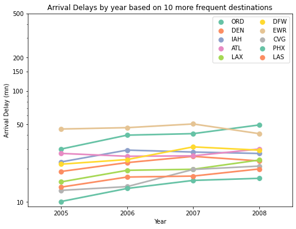

```python
fig = plt.figure(figsize = [8,6])
ax = sb.pointplot(data = df_dest_sorted, x = 'Year', y = 'ArrDelay', hue = 'Dest',
           palette = 'Set2', dodge = 0)
plt.title('Arrival Delays by year based on 10 more frequent destinations')
plt.ylabel('Arrival Delay (mn)')
plt.yscale('log')
plt.yticks([10, 50, 100, 150, 200, 500], [10, 50, 100, 150, 200, 500])
ax.set_yticklabels([],minor = True)
plt.legend(ncol = 2) # re-arrange legend to reduce overlapping
plt.show();
```

The higher arrival delay has been made in 2007 at **EWR** followed by **ORD** and lowest departure delay on **PHX**.

### Talk about some of the relationships you observed in this part of the investigation. Were there features that strengthened each other in terms of looking at your feature(s) of interest?

> About flights cancellation factors, carrier ,NAS and Wheather are more frequent. The majority of flights are could be cancelled due to weather especially in January, February and December just after carrier factor.

### Were there any interesting or surprising interactions between features?

> The more surprising, some destination are always subjected to delays no matter when the departure from origin occured. I'm sure that there are some others interesting features in this set of data. Perhaps with more data or adding data content on other year, i would find others interesting aspects.